# Strategy & data integration

## What is a strategy?

A strategy is simply the allocation of **finite resources** to **actions** in order to achieve an **objective**.

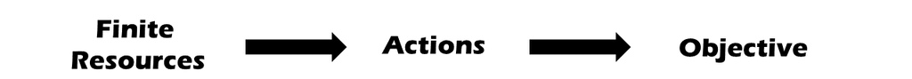

- Without a strategy we risk wasting money and resources without a clear purpose.
- Resourcing is often formalised through budgets
- Good test: no budget = no strategy

## Examples

- To restore an ecosystem (**objective**) through revegetation (**action**) using volunteers (**resource**).
- To overturn the elected government of Ukraine (**objective**) through an armed invasion (**action**) using 140,000 troops amassed on the Ukrainian border (**resource**).
- To protect the ozone layer (**objective**) through the phasing out of chlorofluorocarbons and other ozone depleting chemicals (**action**) using the legislative and regulatory power of 197 governments (**resource**).

## Strategic planning

Every individual or organisation must go through 3 key planning steps in order to construct a strategy:

1. Define an objective
2. Formulate a set of actions
3. Allocate resources to those actions

## Make logical links

- There should be a logical link between resources, actions, and objective (i.e. a theory)
- No link = magical thinking

## Logframes *(logical framework)*

- Is a strategic planning tool used in different phases of project design (esp. proposal and reporting phases)
- Common used in donor funded projects
- A logframe will outline the project’s goals (objective), expected outcomes, activities, and indicators (which measure their success)
- And sometimes: assumptions, deliverables (outputs), and data sources
- Often the logic is revealed using **IF** and **THEN** deduction
- The diagram of this logic = **Theory of Change**
- Funders use different terminology

## Example: *maternal mortality*

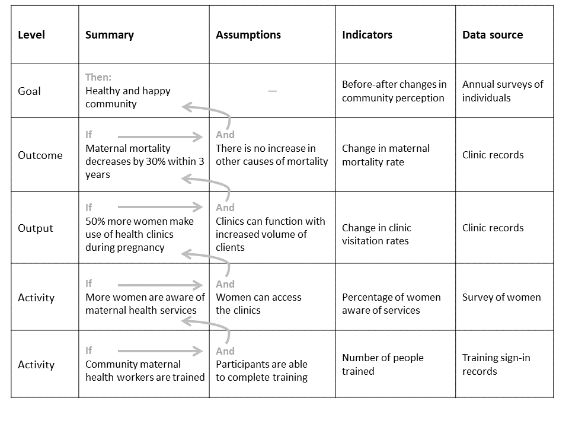

## Downsides

- no agreed terminology
- people within the same organisation interpret it differently
- too often get applied as a prescription (instead of a guideline)
- assumes links are linear, perfect knowledge, and there are no hidden feedback loops
- they often get over engineered and can lead to inane amounts of monitoring
- don’t incorporate data appropriately
- often donors focus on deliverables rather than outcomes
- they are often a time consuming headache

## Upside

- They force projects to have a logic to their strategy
- Prevent magical thinking
- Clear understanding of what is trying to be accomplished and how success will be measured

## The importance of assumptions

- More important than theory are the implicit assumptions which will underpin the strategy

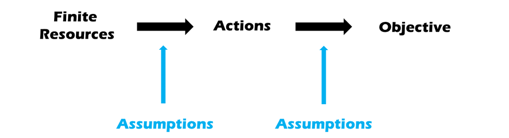

## Assumptions

- Are our assumptions reasonable?
- What does it mean if they are wrong?
- If they are wrong do we abandon an action?
- For this reason logframes and theory-of-change should only be used as a guide never as a prescription.

## Data and strategy

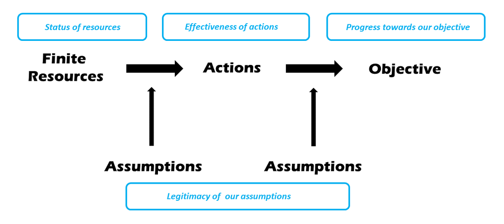

## Status of resources

- Generally going to be simple
- Metric of inventory, capacity or funds remaining *e.g. medical supplies, number of clinic staff, $$ remaining*
- Your financial system: budget tracking

## Effectiveness of actions *(quantifying an outcome)*

Can be simple or complex:

- Metric of what was achieved *e.g. 32% reduction in maternal mortality* or
- Statistical model testing whether or not the intervention was effective (and determining the magnitude of the effect associated with the intervention)
  - *e.g. there was no difference in mortality between control and intervention communities* or
  - *e.g. maybe true mortality only improved by 24% compared to the controls*
- *What does it mean if you honestly reveal your project didn’t succeed?*
- *What does it mean if your target wasn’t reached (and was perhaps never obtainable)?*

## Progress towards our objective

- Simple metric of progress:
  - **Objective:** increase number of students attending school *e.g. % of eligible population <15 years old enrolled in school*
- Or more complex:
  - **Objective:** community happiness *e.g. Before-After changes in a happiness index*
- Objectives can be practical or aspirational

## Legitimacy of our assumptions

Complex and only can be undertaken by high capacity organisations

- Which factors in our assumptions affected the outcome?
  - *e.g. was exposure to the radio campaign a factor in attendance at the clinics*
- Important because it refines how we do similar projects in future

## Watch out for…

- Strategies built around resources that organisations don’t have and can’t reasonably acquire
- Expectation of fast timelines for ecosystem and behavioural change
- Treatment of the implementer: are they being treated as partner or a contractor?
- What happens when the assumptions are wrong? You need avenues for adaptation
- Most field organisations are fighting for their financial survival
- Where is the incentive for honesty?
- **Success** is always relative to the counterfactual

## Summary

- A strategy is simply the allocation of **finite resources** to **actions** in order to achieve an **objective**
- Budgets, logframes, and theory of change attempt capture the strategy
- There is no definitive approach
- Data can, in different ways, help us understand the status of our strategy and whether it is working

## Next up…

*The dark art of data science*